## 🛠“Conociendo el contexto del Problema

Dependiendo del tipo de problema a que nos enfrentemos siempre existe un método para construir alternativas de solución. En la ciencia de datos existen métodos como CRISP-DM (Cross Industry Standard Process for Data Mining).

#### “Cómo se resulven los problemas basados en datos”

[figure not shown]

### Comprensión del negocio: definición del problema

Sea una empresa o una entidad pública siempre partimos de conocer cual es su propósto, cuales cuales son sus objetivos y finalmente si se está trabajando en una un área al interior de una organización debemos de evaluar como se alinean los objetivos del área con los de toda la organización.

Algunas preguntas que nos podemos hacer para conocer el negocio pueden ser las siguientes:

- ¿Qué quiere lograr la organización con este proyecto?
- ¿Qué problema se busca resolver o qué oportunidad se quiere aprovechar?
- ¿Cómo se mide el éxito desde el punto de vista del negocio?

### 🏫 El método de los Factores Críticos de Éxito (FCE)

📈 Otra manera de conocer cual es el propósito de la organización es identificando la Misión, la Visión y los Objetivos, de acuerdo con Rockart (Rockart, 1982) los Factores Críticos de Éxito son aquellos objetivos claves para alcanzar la misión, bajo el riesgo de no cumplirla. Cada una de las acciones se considera como la condición necesaria para el logro de la misión, mientras que el conjunto de factores se considera como la condición suficiente.

🧮 Para saber que se han identificado todos los FCE, o los principales, el equipo que realiza el diagnóstico tiene que preguntarse ¿si cumplimos con la lista de los factores críticos lograremos nuestra meta? Aquí debe existir unanimidad del equipo, si todos están de acuerdo y la respuesta es sí, entonces se puede dar el siguiente paso, mientras que, por el contrario si la respuesta no es unánime y existen otros factores, habrá que incorporarlos y volver a realizar la misma pregunta (Pinto, 2000). Autores como Pinto señalan, que los factores críticos se pueden ordenar para determinar sus prioridades.

- -> Cual es el objetivo de la organización, que la hace diferente de las demás.
- -> Se deben identificar entre 3 y 8 enunciados clave que permitan describir que su cumplimiento permite alcanzar de la misión (FCE).
- -> Una vez identificados se tiene que preguntar ¿si cumplimos con los FCE lograremos nuestra meta?
- -> El siguiente paso es jerarquizar su orden de manera que el primero sea el más apremiante y así sucesivamente con cada unos de los enunciados.
- -> Ahora se identifican aquellos procesos que requieren adecuarse o cambiarse para lograr que el factor crítico contribuya a la misión.
- -> En muchos de los casos es necesario asignar o redireccionar el presupuesto, el personal y todas aquellas acciones que contribuyen al cumplimiento de los FCE.
- -> Los FCE deben ser medibles con el propósito de evaluar si después de los cambios se presentan mejoras.

Para Rockart (Rockart, 1982) los FCE son la herramienta para que los organizaciones identifiquen sus necesidades de información. los sistemas de información son los responsables de darles seguimiento y en su caso proveer alertas que contribuyan a la toma de decisiones. Cada organización tiene sus propios FCE por lo que estos difieren de una organización a otra.

**Ejemplo de aplicación: El caso de la Dependencia “Todos Parejos”**

Para construir el Marco de Diagnóstico, se revisó el manual de orangaización, las reglas de operación entre otros documentos normativos; se realizaron entrevistas con las áreas para identificar sus procesos, sus fuentes de información, el uso de ésta y su repositorios de los datos una vez que ésta era procesada. Se identificó que había islas de información, reprocesos según necesidades particulares de las áreas pero sin comunicación de los cambios o actualizaciones de los datos.

Dos de los propósitos centrales del proyecto consideraban: contar con información para mejorar la toma de decisiones; e institucionalar los datos, para que se pudieran considerar como una fuente confiable, garantizar su integridad como parte del legado de la dependencia, democratizar su acceso para la operación con las debidas restricciones de acuerdo con la naturaleza de los datos.

Para ello se construyó un **Árbol de Problemas** que permitió identificar los síntomas y de ahí avanzar para observar las causas y los efectos.

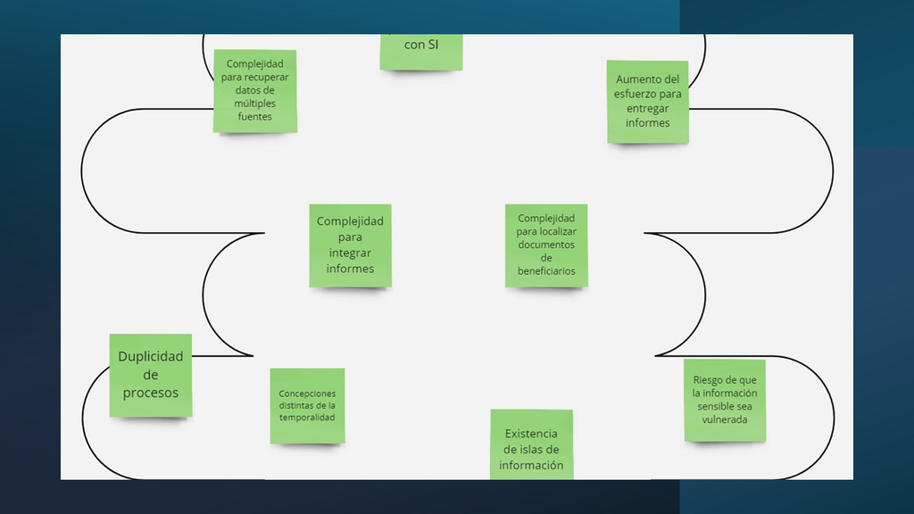

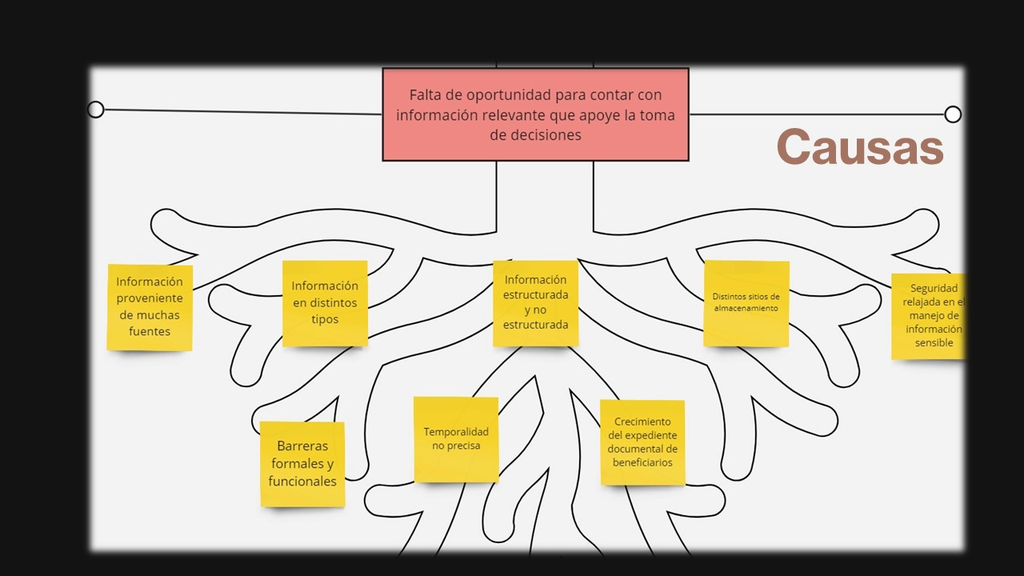

En este parte, para la identificación de los problemas se pueden utilizar otras técnicas como:

- -> El análisis FODA
- -> El analisis Causa-Efecto de Ishikawa
- -> El Cuadro de Mando Integral (CMI)
- -> Y nuestro ya señalado Árbol de Problemas

El resultado del análisis permitió construir una propuesta para integrar todas las fuentes de información, estándarizar los datos, crear un repositorio central (base de datos centralizada y almacenada en la nube) en el que se pudieran integrar y consolidar los datos de los distintos procesos unificando los datos para darle consistencia a la información.

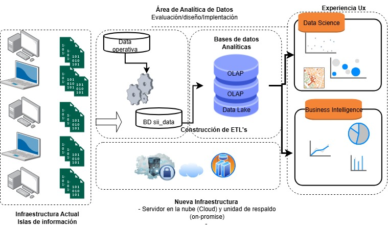

A partir de la consolidación sería posible construir Data Warehouse y Data Lakes de donde se podrían comenzar a construir subsistemas de seguimiento con indicadores para reportar el avance periódico con el Data Warehouse; mientras que, con el Data Lake se pudiera comenzar a realizar el análisis descritivo, prospectivo y prescriptiva.

La propuesta consideró, además, la infraestructura para procesar el flujo de la información hasta producir la información deseada.

### -> Trabajando con Datos: creación de una muestra estratificada

### ->Volver a la página principal